Descriptive Analysis Project Jared Sheridan 2024-04-02

# Descriptive Analytics Project Instructions

## Objective

The objective of this analysis is to analyze the test scores of students across 3 types of tests and what ascpects of thier lives have the buggest effect on overall score.

## Project Requirements

### 1. Dataset Selection

- The dataset I selected for this project is titled Student Study Performance. This dataset shows the correlation between a student’s performance (test scores) and other variables such as Gender, Ethnicity, Parental level of Education, Lunch, and Test preparation. The link for this dataset is: https://www.kaggle.com/datasets/bhavikjikadara/student-study-performance.

```r
student_data <- read.csv("study_performance.csv")

head(student_data)
```

```
##   gender race_ethnicity parental_level_of_education        lunch
## 1 female        group B           bachelor's degree     standard
## 2 female        group C                some college     standard
## 3 female        group B             master's degree     standard
## 4   male        group A          associate's degree free/reduced
## 5   male        group C                some college     standard
## 6 female        group B          associate's degree     standard
##   test_preparation_course math_score reading_score writing_score
## 1                    none         72            72            74
## 2               completed         69            90            88
## 3                    none         90            95            93
## 4                    none         47            57            44
## 5                    none         76            78            75
## 6                    none         71            83            78
```

```r
library(vioplot)
```

### 2. Data Cleaning

- The dataset used in this analysis had zero null values, no extreme outliers, and no really significant discrepencies. The code below shows all blank values and outlines all significant values within the dataset.

```r
summary(student_data)
```

```
##     gender          race_ethnicity     parental_level_of_education
##  Length:1000        Length:1000        Length:1000
##  Class :character   Class :character   Class :character
##  Mode  :character   Mode  :character   Mode  :character
##
##
##
##     lunch           test_preparation_course   math_score     reading_score
##  Length:1000        Length:1000             Min.   :  0.00   Min.   : 17.00
##  Class :character   Class :character        1st Qu.: 57.00   1st Qu.: 59.00
##  Mode  :character   Mode  :character        Median : 66.00   Median : 70.00
##                                             Mean   : 66.09   Mean   : 69.17
##                                             3rd Qu.: 77.00   3rd Qu.: 79.00
##                                             Max.   :100.00   Max.   :100.00
##  writing_score
##  Min.   : 10.00
##  1st Qu.: 57.75
##  Median : 69.00
##  Mean   : 68.05
##  3rd Qu.: 79.00
##  Max.   :100.00
```

```r
colSums(is.na(student_data))
```

```
##                      gender              race_ethnicity
##                           0                           0
## parental_level_of_education                       lunch
##                           0                           0
##     test_preparation_course                  math_score
##                           0                           0
##               reading_score               writing_score
##                           0                           0
```

### 3. Data Handling

- The following data has been identified and transformed into values better suited for analysis.

```r
str(student_data)
```

```
## 'data.frame':    1000 obs. of  8 variables:
##  $ gender                     : chr  "female" "female" "female" "male" ...
##  $ race_ethnicity             : chr  "group B" "group C" "group B" "group A" ...
##  $ parental_level_of_education: chr  "bachelor's degree" "some college" "master's degree" "associate's degree" ...
##  $ lunch                      : chr  "standard" "standard" "standard" "free/reduced" ...
##  $ test_preparation_course    : chr  "none" "completed" "none" "none" ...
##  $ math_score                 : int  72 69 90 47 76 71 88 40 64 38 ...
##  $ reading_score              : int  72 90 95 57 78 83 95 43 64 60 ...
##  $ writing_score              : int  74 88 93 44 75 78 92 39 67 50 ...
```

```r
student_data$gender <- as.numeric(factor(student_data$gender)) - 1

student_data$lunch <- as.numeric(factor(student_data$lunch)) - 1

student_data$test_preparation_course <- as.numeric(factor(student_data$test_preparation_course)) - 1

student_data$parental_level_of_education <- as.numeric(factor(student_data$parental_level_of_education)) - 1

student_data$race_ethnicity <- as.numeric(factor(student_data$race_ethnicity)) - 1

average_score <- mean(student_data$math_score + student_data$reading_score + student_data$writing_score)

summary(student_data)
```

```
##      gender      race_ethnicity  parental_level_of_education     lunch
##  Min.   :0.000   Min.   :0.000   Min.   :0.000               Min.   :0.000
##  1st Qu.:0.000   1st Qu.:1.000   1st Qu.:1.000               1st Qu.:0.000
##  Median :0.000   Median :2.000   Median :2.000               Median :1.000
##  Mean   :0.482   Mean   :2.174   Mean   :2.486               Mean   :0.645
##  3rd Qu.:1.000   3rd Qu.:3.000   3rd Qu.:4.000               3rd Qu.:1.000
##  Max.   :1.000   Max.   :4.000   Max.   :5.000               Max.   :1.000
##  test_preparation_course   math_score     reading_score    writing_score
##  Min.   :0.000           Min.   :  0.00   Min.   : 17.00   Min.   : 10.00
##  1st Qu.:0.000           1st Qu.: 57.00   1st Qu.: 59.00   1st Qu.: 57.75
##  Median :1.000           Median : 66.00   Median : 70.00   Median : 69.00
##  Mean   :0.642           Mean   : 66.09   Mean   : 69.17   Mean   : 68.05
##  3rd Qu.:1.000           3rd Qu.: 77.00   3rd Qu.: 79.00   3rd Qu.: 79.00
##  Max.   :1.000           Max.   :100.00   Max.   :100.00   Max.   :100.00
```

### 4. Descriptive Analysis

- The following histograms show the spread of test scores across the three tests. The violin plot shows how students who completed the test preparation course had higher combined scores than those that did not complete the preparation course. Listed below the visuals are the correlation models which show what aspects of the students have the highest effect on test scores.

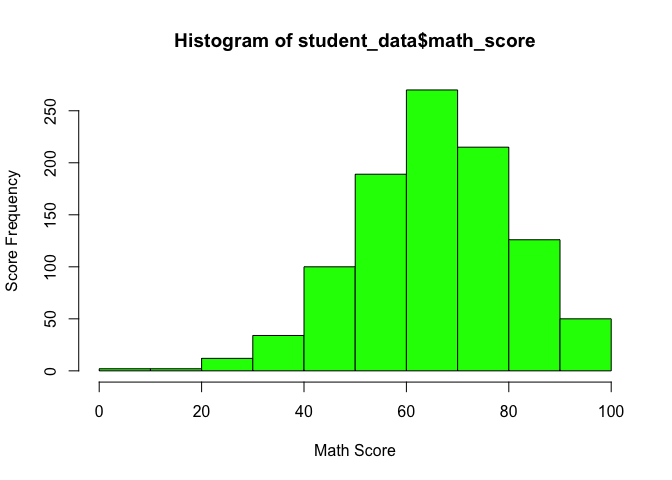

```r
math_hist <- hist(student_data$math_score, ylab = "Score Frequency", xlab = "Math Score",
                  col = "green")
```

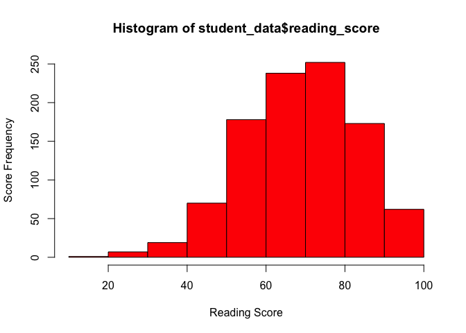

```r
read_hist <- hist(student_data$reading_score, ylab = "Score Frequency", xlab = "Reading Score",
                  col = "red")
```

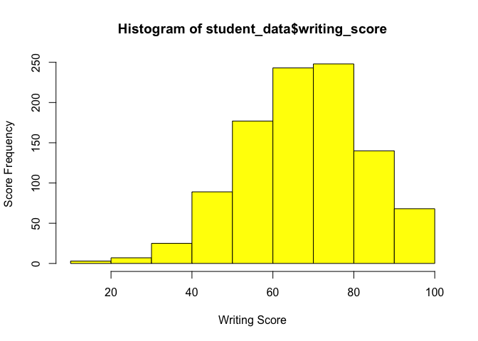

```r
write_hist <- hist(student_data$writing_score, ylab = "Score Frequency", xlab = "Writing Score",
                   col = "yellow")
```

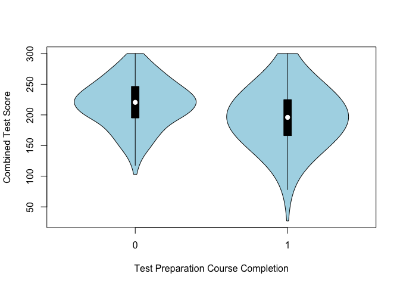

```r
vioplot(math_score + reading_score + writing_score ~ test_preparation_course, data = student_data,
        ylab = "Combined Test Score", xlab = "Test Preparation Course Completion",
        col = "lightblue")
```

```r
cmodel <- lm(math_score + reading_score + writing_score ~ gender + race_ethnicity + parental_level_of_education +  lunch + test_preparation_course, data=student_data)
cmodel
```

```
##
## Call:
## lm(formula = math_score + reading_score + writing_score ~ gender +
##     race_ethnicity + parental_level_of_education + lunch + test_preparation_course,
##     data = student_data)
##
## Coefficients:
##                 (Intercept)                       gender
##                     198.793                      -11.827
##              race_ethnicity  parental_level_of_education
##                       6.071                       -1.905
##                       lunch      test_preparation_course
##                      25.939                      -23.325
```

```r
cor_matrix <-  cor(student_data)
cor_matrix
```

```
##                                   gender race_ethnicity
## gender                       1.000000000   -0.001501924
## race_ethnicity              -0.001501924    1.000000000
## parental_level_of_education  0.001913078   -0.031945647
## lunch                        0.021371670    0.046562590
## test_preparation_course     -0.006027952   -0.017508038
## math_score                   0.167982238    0.216415448
## reading_score               -0.244312608    0.145252622
## writing_score               -0.301224936    0.165690511
##                             parental_level_of_education       lunch
## gender                                      0.001913078 0.021371670
## race_ethnicity                             -0.031945647 0.046562590
## parental_level_of_education                 1.000000000 0.006319907
## lunch                                       0.006319907 1.000000000
## test_preparation_course                    -0.023968340 0.017044085
## math_score                                 -0.068279267 0.350876646
## reading_score                              -0.072443637 0.229560322
## writing_score                              -0.084299315 0.245768676
##                             test_preparation_course  math_score reading_score
## gender                                 -0.006027952  0.16798224   -0.24431261
## race_ethnicity                         -0.017508038  0.21641545    0.14525262
## parental_level_of_education            -0.023968340 -0.06827927   -0.07244364
## lunch                                   0.017044085  0.35087665    0.22956032
## test_preparation_course                 1.000000000 -0.17770247   -0.24178043
## math_score                             -0.177702469  1.00000000    0.81757966
## reading_score                          -0.241780434  0.81757966    1.00000000
## writing_score                          -0.312946284  0.80264205    0.95459808
##                             writing_score
## gender                        -0.30122494
## race_ethnicity                 0.16569051
## parental_level_of_education   -0.08429931
## lunch                          0.24576868
## test_preparation_course       -0.31294628
## math_score                     0.80264205
## reading_score                  0.95459808
## writing_score                  1.00000000
```

## Resources

- https://www.kaggle.com/datasets/bhavikjikadara/student-study-performance.